# Anàlisi de dades òmiques. PAC 1

Marta Domingo Domènech

2025-04-02

## 1. Selecció de dades

```r
library(readxl)
Datacat <- read_excel("../metaboData/Data_Catalog.xlsx")
colnames(Datacat)
```

```
## [1] "Dataset"     "Samples"     "Features"    "Description"
```

```r
head(Datacat)
```

```
## # A tibble: 6 × 4
##   Dataset                          Samples Features Description
##   <chr>                              <dbl>    <dbl> <chr>
## 1 2018-MetabotypingPaper                39      690 "Data used in the paper \"M…
## 2 2018-Phosphoproteomics                12     1320 "The acompanying dataset ha…
## 3 2023-CIMCBTutorial                   140      149 "NMR data from a gastric ca…
## 4 2023-UGrX-4MetaboAnalystTutorial      24      145 "Data from MetabolomicsWork…
## 5 2024-fobitools-UseCase_1              45     1541 "This dataset is used in th…
## 6 2024-Cachexia                         77       63 "Cachexia is a complex meta…
```

```r
Datacat$Description
```

```
## [1] "Data used in the paper \"Metabotypes of response to bariatric surgery independent of the magnitude of weight loss\""
## [2] "The acompanying dataset has been obtained from a phosphoproteomics experiment that was performed to analyze (3 + 3) PDX models of two different subtypes using Phosphopeptide enriched samples."
## [3] "NMR data from a gastric cancer study used in a metabolomics data analysis tutorial (\"Basic Metabolomics Data Analysis Workflow\" (https://cimcb.github.io/MetabWorkflowTutorial/Tutorial1.html)"
## [4] "Data from MetabolomicsWorkbench (ID ST000002)"
## [5] "This dataset is used in the fobitools Bioconductor package, in one its vignettes, [Use Case ST000291] analyzing the data from Metabolomics Workbench  Dataset"
## [6] "Cachexia is a complex metabolic syndrome associated with an underlying illness (such as cancer) and characterized by loss of muscle with or without loss of fat mass (Evans et al., 2008). A total of 77 urine samples were collected being 47 of them patients with cachexia, and 30 control patien…
```

Després d’haver llegit la descripció de cada data set, escullo treballar amb el segon data set: “2018-Phosphoproteomics”.

```r
# Codi per accedir al data set (2018-Phosphoproteomics) escollit des del repositori de git hub clonat al directori local del meu pc.

DataSetPhospho <- read_excel("../metaboData/Datasets/2018-Phosphoproteomics/TIO2+PTYR-human-MSS+MSIvsPD.xlsx")
colnames(DataSetPhospho)
```

```
##  [1] "SequenceModifications" "Accession"             "Description"
##  [4] "Score"                 "M1_1_MSS"              "M1_2_MSS"
##  [7] "M5_1_MSS"              "M5_2_MSS"              "T49_1_MSS"
## [10] "T49_2_MSS"             "M42_1_PD"              "M42_2_PD"
## [13] "M43_1_PD"              "M43_2_PD"              "M64_1_PD"
## [16] "M64_2_PD"              "CLASS"                 "PHOSPHO"
```

```r
head(DataSetPhospho)
```

```
## # A tibble: 6 × 18
##   SequenceModifications   Accession Description Score M1_1_MSS M1_2_MSS M5_1_MSS
##   <chr>                   <chr>     <chr>       <dbl>    <dbl>    <dbl>    <dbl>
## 1 LYPELSQYMGLSLNEEEIR[2]… O00560    Syntenin-1…  48.1     24.3   44476.       0
## 2 VDKVIQAQTAFSANPANPAILS… O00560    Syntenin-1…  67.0      0     43139.    2102.
## 3 VIQAQTAFSANPANPAILSEAS… O00560    Syntenin-1…  77.7   3413.   172143.   77323.
## 4 HADAEMTGYVVTR[6] Oxida… O15264    Mitogen-ac…  44.9 220431.   145657.  104288.
## 5 HADAEMTGYVVTR[9] Phosp… O15264    Mitogen-ac…  67.4  18255.     8530.   35956.
## 6 STGPGASLGTGYDR[12] Pho… O15551    Claudin-3 …  63.7 644513.   261938.  187023.
## # ℹ 11 more variables: M5_2_MSS <dbl>, T49_1_MSS <dbl>, T49_2_MSS <dbl>,
## #   M42_1_PD <dbl>, M42_2_PD <dbl>, M43_1_PD <dbl>, M43_2_PD <dbl>,
## #   M64_1_PD <dbl>, M64_2_PD <dbl>, CLASS <chr>, PHOSPHO <chr>
```

## 2. Creació d’un objecte de la classe SummarizedExperiment.

Ha de contenir les dades i les metadades (informació sobre el dataset, les seves files i columnes).

```r
library(S4Vectors)
library(SummarizedExperiment)
```

1. Creació del dataframe anomenat “row_data” amb la informació de cada feature (fila). En aquest dataframe hi recollirem les metadades de cada feature: “SequenceModifications, Accession, Description, Score, CLASS, PHOSPHO”:

```r
row_data <- DataFrame(
  SequenceModifications = DataSetPhospho$SequenceModifications,
  Accession = DataSetPhospho$Accession,
  Description = DataSetPhospho$Description,
  Score = DataSetPhospho$Score,
  CLASS = DataSetPhospho$CLASS,
  PHOSPHO = DataSetPhospho$PHOSPHO
)

# Definició dels rownames amb la informació de la columna "Accession".
rownames(row_data) <- row_data$Accession
```

2. Construcció de la matriu “assay_matrix” amb les columnes del dataset les quals contenent les dades númeriques:

```r
assay_matrix <- as.matrix(
DataSetPhospho[, c("M1_1_MSS", "M1_2_MSS", "M5_1_MSS", "M5_2_MSS",
"T49_1_MSS", "T49_2_MSS",
"M42_1_PD", "M42_2_PD", "M43_1_PD", "M43_2_PD",
"M64_1_PD", "M64_2_PD")]
)
```

```r
# Assignació dels mateixos noms de fila que a rowData (row_data).
rownames(assay_matrix) <- rownames(row_data)
```

```r
sample_names <- c("M1_1_MSS", "M1_2_MSS", "M5_1_MSS", "M5_2_MSS",
                  "T49_1_MSS", "T49_2_MSS", "M42_1_PD", "M42_2_PD",
                  "M43_1_PD", "M43_2_PD", "M64_1_PD", "M64_2_PD")
method <- c(rep("MSS", 6), rep("PD", 6))

col_data <- DataFrame(
  sample = sample_names,
  method = method
)

# Fer coincidir rownames(col_data) amb la matriu
rownames(col_data) <- col_data$sample

col_data
```

```
## DataFrame with 12 rows and 2 columns
##                sample      method
##           <character> <character>
## M1_1_MSS     M1_1_MSS         MSS
## M1_2_MSS     M1_2_MSS         MSS
## M5_1_MSS     M5_1_MSS         MSS
## M5_2_MSS     M5_2_MSS         MSS
## T49_1_MSS   T49_1_MSS         MSS
## ...               ...         ...
## M42_2_PD     M42_2_PD          PD
## M43_1_PD     M43_1_PD          PD
## M43_2_PD     M43_2_PD          PD
## M64_1_PD     M64_1_PD          PD
## M64_2_PD     M64_2_PD          PD
```

```r
# Codi per reordenar les dades de col_data en cas de que no coincideixen amb les de la matriu assay_matrix:
col_data <- col_data[colnames(assay_matrix), ]
col_data
```

```
## DataFrame with 12 rows and 2 columns
##                sample      method
##           <character> <character>
## M1_1_MSS     M1_1_MSS         MSS
## M1_2_MSS     M1_2_MSS         MSS
## M5_1_MSS     M5_1_MSS         MSS
## M5_2_MSS     M5_2_MSS         MSS
## T49_1_MSS   T49_1_MSS         MSS
## ...               ...         ...
## M42_2_PD     M42_2_PD          PD
## M43_1_PD     M43_1_PD          PD
## M43_2_PD     M43_2_PD          PD
## M64_1_PD     M64_1_PD          PD
## M64_2_PD     M64_2_PD          PD
```

4. Creació de l’objecte SummarizedExperiment.

```r
se_object <- SummarizedExperiment(
  assays = list(abundance = assay_matrix),
  rowData = row_data,
  colData = col_data
)
```

5. Revisió de l’objecte creat “se_object”.

```r
se_object  # Mostra el resum de l'objecte.
```

```
## class: SummarizedExperiment
## dim: 1438 12
## metadata(0):
## assays(1): abundance
## rownames(1438): O00560 O00560 ... Q13283 Q9NYF8
## rowData names(6): SequenceModifications Accession ... CLASS PHOSPHO
## colnames(12): M1_1_MSS M1_2_MSS ... M64_1_PD M64_2_PD
## colData names(2): sample method
```

```r
dim(se_object) # Hauria de ser 1438 features x 12 mostres.
```

```
## [1] 1438   12
```

```r
rowData(se_object) # Metadades de cada feature.
```

```
## DataFrame with 1438 rows and 6 columns
##         SequenceModifications   Accession            Description     Score
##                   <character> <character>            <character> <numeric>
## O00560 LYPELSQYMGLSLNEEEIR[..      O00560 Syntenin-1 OS=Homo s..     48.07
## O00560 VDKVIQAQTAFSANPANPAI..      O00560 Syntenin-1 OS=Homo s..     67.05
## O00560 VIQAQTAFSANPANPAILSE..      O00560 Syntenin-1 OS=Homo s..     77.71
## O15264 HADAEMTGYVVTR[6] Oxi..      O15264 Mitogen-activated pr..     44.87
## O15264 HADAEMTGYVVTR[9] Pho..      O15264 Mitogen-activated pr..     67.42
## ...                       ...         ...                    ...       ...
## Q12792 YLLSQSSPAPLTAAEEELR[..      Q12792 Twinfilin-1 OS=Homo ..     56.19
## Q13177   YLSFTPPEK[3] Phospho      Q13177 Serine/threonine-pro..     39.14
## O95218 YNLDASEEEDSNK[6] Pho..      O95218 Zinc finger Ran-bind..     80.66
## Q13283 YQDEVFGGFVTEPQEESEEE..      Q13283 Ras GTPase-activatin..     40.01
## Q9NYF8 YSPSQNSPIHHIPSRR[1] ..      Q9NYF8 Bcl-2-associated tra..     36.71
##              CLASS     PHOSPHO
##        <character> <character>
## O00560           H           Y
## O00560           H           Y
## O00560           H           Y
## O15264           H           Y
## O15264           H           Y
## ...            ...         ...
## Q12792           C         S/T
## Q13177           C         S/T
## O95218           C         S/T
## Q13283           C         S/T
## Q9NYF8           C         S/T
```

```r
colData(se_object) # Metadades de cada mostra.
```

```
## DataFrame with 12 rows and 2 columns
##                sample      method
##           <character> <character>
## M1_1_MSS     M1_1_MSS         MSS
## M1_2_MSS     M1_2_MSS         MSS
## M5_1_MSS     M5_1_MSS         MSS
## M5_2_MSS     M5_2_MSS         MSS
## T49_1_MSS   T49_1_MSS         MSS
## ...               ...         ...
## M42_2_PD     M42_2_PD          PD
## M43_1_PD     M43_1_PD          PD
## M43_2_PD     M43_2_PD          PD
## M64_1_PD     M64_1_PD          PD
## M64_2_PD     M64_2_PD          PD
```

```r
head(assays(se_object)$abundance) # Les primere files de la matriu de dades.
```

```
##            M1_1_MSS   M1_2_MSS   M5_1_MSS   M5_2_MSS    T49_1_MSS  T49_2_MSS
## O00560     24.29438  44475.964      0.000   6269.141    1135.8169   21933.90
## O00560      0.00000  43138.904   2102.056  50355.051     248.9275    3239.16
## O00560   3412.60332 172143.040  77323.019 307637.429   98442.2773  192982.37
## O15264 220431.17880 145656.887 104287.815  75887.365  773377.4981  481165.54
## O15264  18254.77813   8529.755  35955.901  44102.316   57145.1682   34638.01
## O15551 644513.31840 261938.025 187023.484 124867.715 4487443.6920 2572575.27
##           M42_1_PD   M42_2_PD     M43_1_PD    M43_2_PD    M64_1_PD     M64_2_PD
## O00560       0.000       0.00     772.9056    2136.746    1820.724    1727.9098
## O00560    1315.904       0.00       0.0000       0.000       0.000     892.3565
## O00560   24851.344   16547.95    5565.2821       0.000    3264.563    5901.9577
## O15264 1027196.292 1163747.38 4080239.1820 4885818.113 3093786.793 2759104.5440
## O15264   21231.256   49499.70  666107.0448  379313.615  255792.117  579765.0018
## O15551  535809.187  434645.89   91361.8781   65997.913  243250.439  206632.6444
```

### 2.1. SummarizedExperiment vs ExpressionSet

La classe SummarizedExperiment es pot considerar una evolució o substitució més recent de la classe ExpressionSet dins lʼecosistema de Bioconductor. Tot i que comparteixen la idea bàsica de contenir dades dʼexpressió i metadades associades, SummarizedExperiment presenta diverses diferències rellevants.

**Diferències estructurals:**

1. **Estructura dʼemmagatzematge de dades:**
   - ExpressionSet disposa dʼun sol array dʼexpressió (exprs).
   - SummarizedExperiment admet múltiples “assays” en el compartiment assays, útil per gestionar conjuntament dades crues, normalitzades o dʼaltres tipus en un mateix objecte.
2. **Informació genòmica integrada (rowRanges):**
   - ExpressionSet no incorpora informació sobre les posicions genòmiques.
   - SummarizedExperiment inclou el compartiment rowRanges, que emmagatzema coordenades i metadades genòmiques de cada fila, útil per a dades de seqüenciació.
3. **Metadades en forma de DataFrame:**
   - ExpressionSet utilitza pData (per a mostres) i fData (per a característiques) com slots de metadades, que són data.frames base de R.
   - SummarizedExperiment empra colData (per a mostres) i rowData (per a característiques) que són objectes de tipus DataFrame, més flexibles i consistents amb altres paquets bioconductor.

**Versatilitat i escalabilitat:**

- ExpressionSet va ser concebut principalment per a dades de microarrays, amb una sola matriu dʼexpressió.
- SummarizedExperiment és més flexible i pensat per gestionar dades dʼRNA-seq, ATAC-seq, proteòmica, metabolòmica i altres dades multimodals, gràcies a la possibilitat de tenir múltiples assays i integració amb la infraestructura genòmica.

**Integració amb Bioconductor:**

- SummarizedExperiment sʼha convertit en lʼestàndard per a moltes eines i fluxos de treball Bioconductor, especialment aquells que fan servir GenomicRanges.
- ExpressionSet encara es fa servir en aplicacions i paquets antics, però la majoria de paquets nous de Bioconductor opten per SummarizedExperiment.

En resum, SummarizedExperiment és una classe més flexible i adaptada a lʼanàlisi multimodal i amb integració genòmica, mentre que ExpressionSet sʼenfoca en un únic array dʼexpressió i amb metadades més senzilles. Això fa que SummarizedExperiment sigui lʼopció recomanada en la major part de pipelines de dades òmiques actuals.

## 3. Anàlisi exploratòria de les dades “DataSetPhospho”

```r
# Definició de les dades en una variable.
Phospho <- assays(se_object)$abundance # Defining the data on a variable.
Phospho <- data.frame(Phospho)
Phospho
```

[output not shown]

[output cut: 4262 more lines]

[output not shown]

```r
dim(Phospho)
```

```
## [1] 1438   12
```

```r
names(Phospho)
```

```
##  [1] "M1_1_MSS"  "M1_2_MSS"  "M5_1_MSS"  "M5_2_MSS"  "T49_1_MSS" "T49_2_MSS"
##  [7] "M42_1_PD"  "M42_2_PD"  "M43_1_PD"  "M43_2_PD"  "M64_1_PD"  "M64_2_PD"
```

```r
# Estadístiques per columna.
data.frame(round(apply(Phospho,2, summary)))
```

```
##         M1_1_MSS M1_2_MSS M5_1_MSS M5_2_MSS T49_1_MSS T49_2_MSS M42_1_PD
## Min.           0        0        0        0         0         0        0
## 1st Qu.     5653     5497     2573     3273      9306      8611     5341
## Median     30682    26980    20801    26241     55641     46110    36854
## Mean      229841   253151   232967   261067    542449    462616   388424
## 3rd Qu.   117373   113004   113958   130132    223103    189141   180252
## Max.    16719906 43928481 15135169 19631820  49218872  29240206 48177680
##         M42_2_PD M43_1_PD M43_2_PD M64_1_PD M64_2_PD
## Min.           0        0        0        0        0
## 1st Qu.     4216    19641    17299    11038     8660
## Median     30533    67945    59607    52249    47330
## Mean      333587   349020   358822   470655   484712
## 3rd Qu.   152088   205471   201924   209896   206036
## Max.    42558111 35049402 63082982 71750330 88912734
```

Amb el resum estadístic es pot observar l’escala de les dades. En aquest cas, el que crida l’atenció és veure la diferència entre els valors mínims i els valors màixims que van del zero a valors de magnitud de $10^7$. Això indica que s’hauran de tractar les dades abans de començar a estudiar-les amb mètodes estadísitcs.

Els histogrames i els bloxpots són una bona eina per vitsualitzar les dades de manera gràfica.

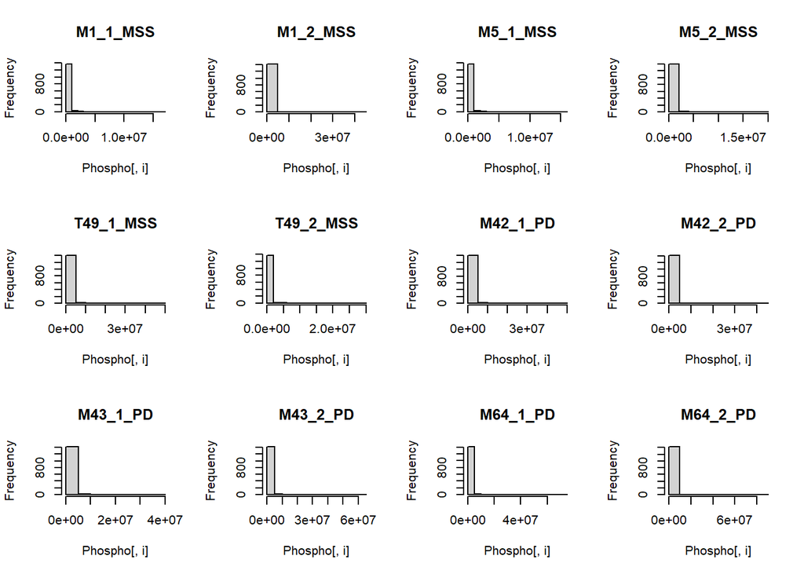

```r
# Histogrames de les dades originals
histo <- par(mfrow = c(3, 4))
for (i in 1:ncol(Phospho)) {
  hist(Phospho[, i], main = names(Phospho)[i])
}
```

```r
par(histo)
```

L’histograma evidència que cal aplicar una transformació logarítmica per rebaixar els valors més alts i expandir els més petits, disminuïnt així la diferència entre ambdos valors.

En un dataset on la variable “x” pot prendre el valor zero (o valors molt petits), log(x) és matemàticament problemàtic quan x = 0, perquè log(0) no està definit (és -∞). Per això, sovint s’utilitza log(x + 1):  
• Si x = 0, llavors log(1) = 0, de manera que no es produeix cap error ni valor infinit.  
• Això evita haver d’eliminar les observacions que tinguin x = 0 (cosa que podria esbiaixar l’anàlisi).  
• És una transformació comuna en casos on x representa coses com comptes (counts), on zero pot tenir un significat estadísticament rellevant.

```r
Phospho_log <- Phospho
Phospho_log <- log(Phospho_log + 1)

View(Phospho_log)
```

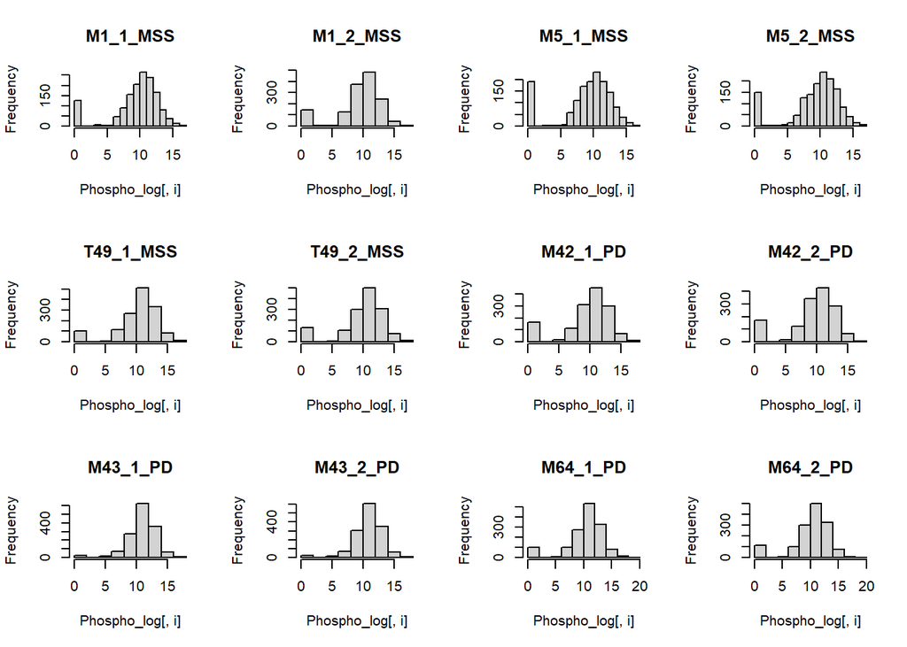

```r
histo_log <- par(mfrow=c(3,4))

for (i in 1:ncol(Phospho_log))
  hist(Phospho_log[,i], main = names(Phospho_log)[i])
```

```r
par(histo_log)
```

Una opció millor és fer servir boxplots, que permeten visualitzar totes les mostres alhora i ofereixen pistes sobre la conveniència de fer algun tipus de preprocessament.

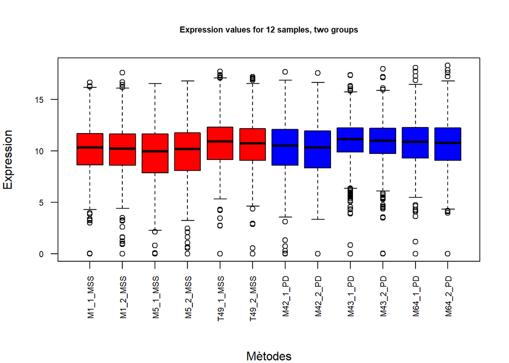

```r
# Boxplot amb les dades tractades pel logaritme (Phospho_log).
par(mar=c(7, 4, 4, 2))
groupColor <- c(rep("red", 6), rep("blue", 6))

boxplot(Phospho_log, col=groupColor, main="Expression values for 12 samples, two groups",
        xlab="",
        ylab="Expression", las=2, cex.axis=0.7, cex.main=0.7)
mtext(
  "Mètodes",
  side = 1,
  line = 6
)
```

Havent vist l’heterogeneïtat de les dades mitjançant bloxplot i histogrames i tenint en compte que totes les variables són del mateix tipus, per poder aplicar un anàlisi multivariant correctament, s’han de centrar i normalitzar:

```r
# Centralització i normalització de les dades
Phospho_log_centered <- scale(Phospho_log, center = TRUE, scale = TRUE)
```

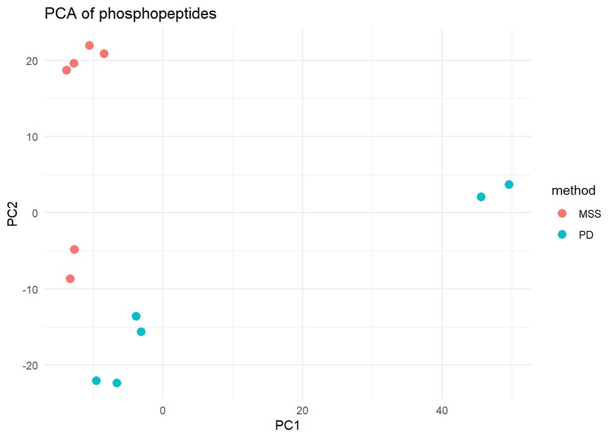

```r
library(ggplot2)
library(dplyr)
# Anàlisi multivariant: PCA --> prcomp
pca <- prcomp(t(Phospho_log_centered), scale. = TRUE)

# Visualització del PCA
pca_data <- data.frame(pca$x)
pca_data$method <- col_data$method

ggplot(pca_data, aes(x = PC1, y = PC2, color = method)) +
  geom_point(size = 3) +
  labs(title = "PCA of phosphopeptides", x = "PC1", y = "PC2") +
  theme_minimal()
```

Quan les dades contenent més variables que observacions el mètode princomp() no és tan felxible com el prcomp i no és capaç de fer el càlcul multivariant. Per això si intentem executar aquesta funció ens apareix un missatge d’error indicant “princomp can only be used with more units than variable”.

Per evitar confusions degut a l’efecte batch, és a dir evitar variacions sitemàtiques les quals no estan relacionades amb les variables d’interès, sino amb amb el processament de les mostres, es duen a terme una sèrie d’anàlisis. En aquest cas només es realitzaran anàlisis de detecció.

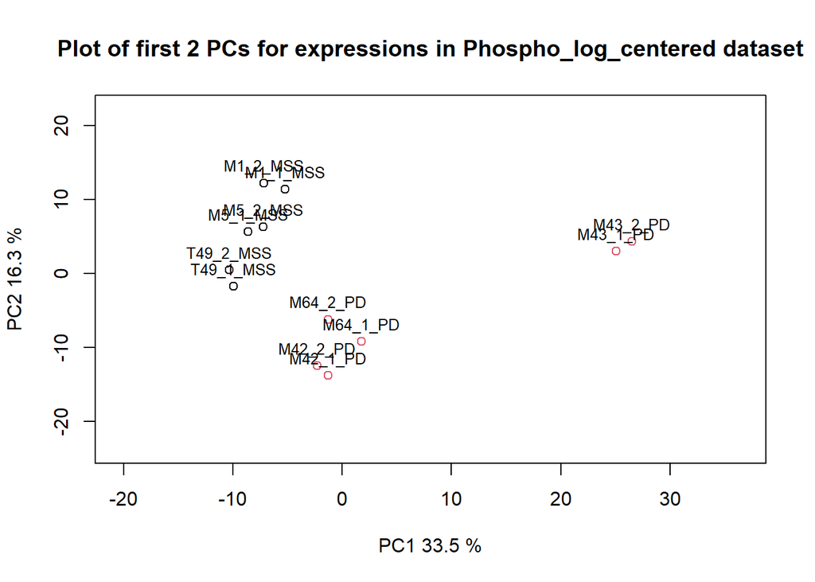

```r
X <- Phospho_log_centered
# Funció plotPCA
plotPCA <- function ( X, labels=NULL, colors=NULL, dataDesc="", scale=FALSE, cex4text=0.8)
{
  pcX <- prcomp(t(X), scale.=scale)  # Utilitzar t(X) per transposar la matriu
  loads <- round(pcX$sdev^2/sum(pcX$sdev^2)*100, 1)
  xlab <- c(paste("PC1", loads[1], "%"))
  ylab <- c(paste("PC2", loads[2], "%"))
  if (is.null(colors)) colors <- 1
  plot(pcX$x[, 1:2], xlab=xlab, ylab=ylab, col=colors,
       xlim=c(min(pcX$x[, 1])-10, max(pcX$x[, 1])+10),
       ylim=c(min(pcX$x[, 2])-10, max(pcX$x[, 2])+10))
  text(pcX$x[, 1], pcX$x[, 2], labels, pos=3, cex=cex4text)
  title(paste("Plot of first 2 PCs for expressions in", dataDesc, sep=" "), cex=0.8)
}

# Aplicar la funció plotPCA al dataset Phospho_log_centered.
labels <- col_data$sample
colors <- as.numeric(factor(col_data$method))
dataDesc <- "Phospho_log_centered dataset"

plotPCA(Phospho_log_centered, labels=labels, colors=colors, dataDesc=dataDesc)
```

Per últim executarem un estudi basat en distàncies amb la funció heatmap(). Aquest estudi consisteix en calcular una matriu de distàncies i visualitzant-la mitjançant un mapa de colors.

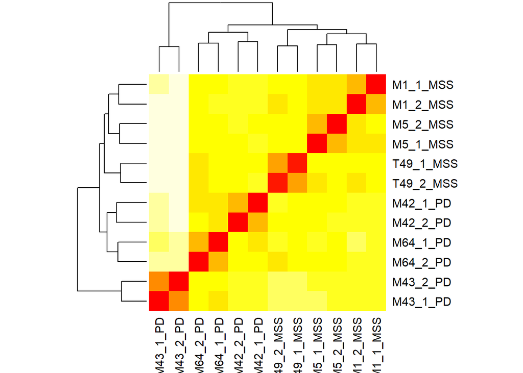

```r
manDist <- dist(t(X))
heatmap (as.matrix(manDist), col=heat.colors(16))
```